# Some one-way ANOVA examples

## Load packages

```r
library(magrittr)
```

## Exercise 19.1 (source: “The Book of R” by Tillman Davies)

*a./b. checks for normality of each group and constant variance across the groups*

```r
depths<-c(93,120,65,105,115,82,99,87,100,90,78,95,93,88,110,85,45,80,28,75,70,65,55,50,40,100,75,65,40,73,65,50,30,45,50,45,55,96,58,95,90,65,80,85,95,82)

siteNums<-rep(strsplit("Site1 Site2 Site3 Site4"," ")%>%unlist,times=c(15,10,12,9))

df<-data.frame(depth=depths,siteNum=siteNums)
```

Now let’s check for normality of depths at each site and constant variance of depths across sites. We’ll assume that depths at a particular site are independent of one another and that the depths at one of the four sites are independent of those at any other of the four sites.

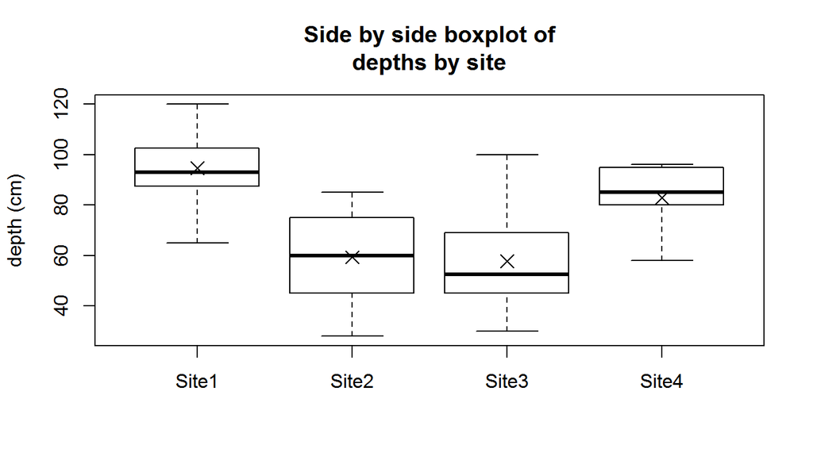

```r
boxplot(df$depth~df$siteNum,main="Side by side boxplot of\ndepths by site",ylab="depth (cm)")
siteMeans<-with(df,tapply(depth,siteNum,FUN=mean))
points(1:4,siteMeans,pch=4,cex=1.5)
```

Let’s check to see that the ratio of the largest group standard deviation to the smallest one is less than 2.

```r
sds<-with(df,tapply(depth,siteNum,FUN=sd))
max(sds)/min(sds)
```

```
## [1] 1.399928
```

It’s well below 2, so we’re good on the constant variance assumption.

To examine normality with each group a bit further, we’ll look at an NPP plot of the group residuals. (uses siteMeans from above)

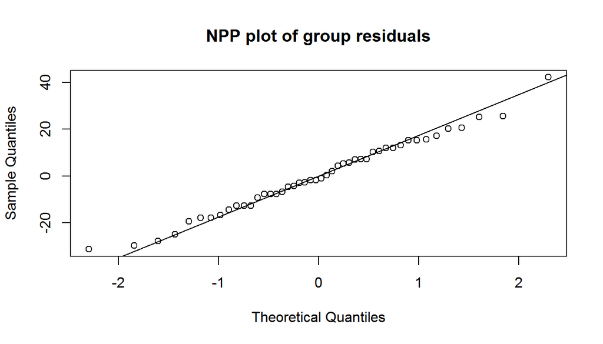

```r
grpResids<-df$depth - siteMeans[as.numeric(df$siteNum)]
qqnorm(grpResids,main="NPP plot of group residuals")
qqline(grpResids)
```

So the assumption normality of each group seems quite reasonable.

*c. Single factor ANOVA on depths vs site*

$H_0$ : mean depth of finding is seem across all sites  
$H_A$ : at least one pair of sites contains differing mean depths

```r
test<-aov(depth~siteNum,df)
summary(test)
```

```
##             Df Sum Sq Mean Sq F value   Pr(>F)
## siteNum      3  12397    4132   15.14 7.99e-07 ***
## Residuals   42  11465     273
## ---
## Signif. codes:  0 '***' 0.001 '**' 0.01 '*' 0.05 '.' 0.1 ' ' 1
```

So we have a massive F-score and a miniscule P-value ($O(10^{-6})$), so we can comfortably reject the null hypothesis that the mean depth of findings is the same at all archaelogical sites.

*d./e. Using the iris dataset, determine which among sepal width, petal width, sepal length, and petal length would be suitable for one-way ANOVA using Species as the grouping variable. Then perform the one-way ANOVA procedure.*

Let’s see if Sepal.Length is suitable for ANOVA w/ Species as grouping variable.

```r
nrow(iris) - nrow(iris[complete.cases(iris),])
```

```
## [1] 0
```

```r
## so no missing values for any variable of iris dataset
with(iris,boxplot(Sepal.Length~Species,main="Side-by-side boxplot of\n Sepal Length vs Species\n for iris"))
sepalLengthMeans<-with(iris,tapply(Sepal.Length,Species,FUN=mean))
sepalLengthMeans
```

```
##     setosa versicolor  virginica
##      5.006      5.936      6.588
```

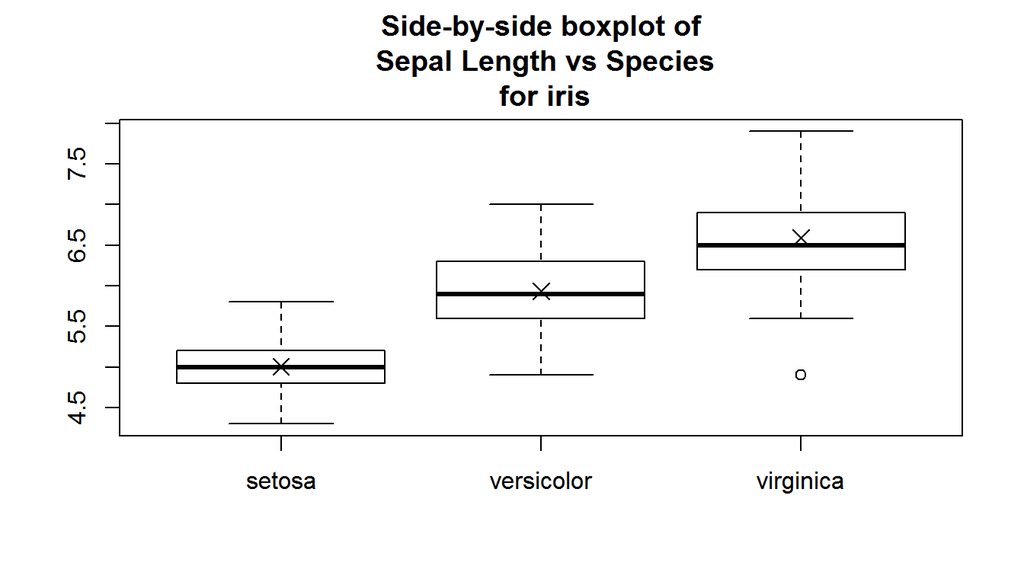

```r
points(x=seq_along(iris$Species%>%unique),y=sepalLengthMeans,pch=4,cex=1.5)
```

```r
sepalLengthSDs<-with(iris,tapply(Sepal.Length,Species,FUN=sd))

max(sepalLengthSDs)/min(sepalLengthSDs)
```

```
## [1] 1.803967
```

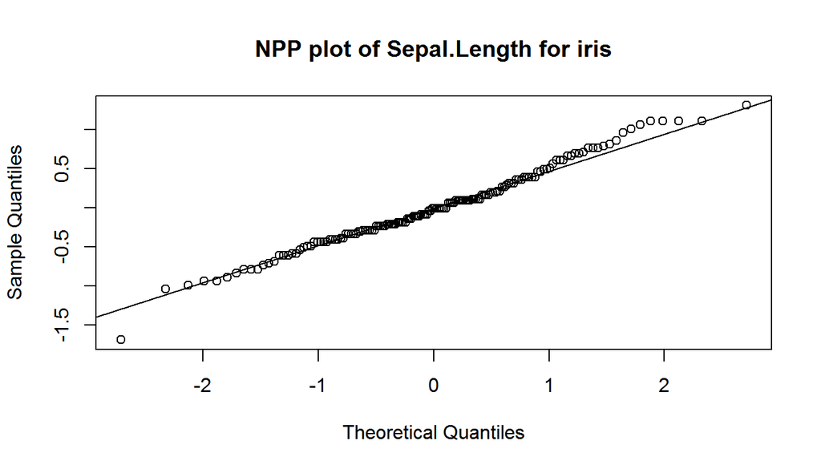

```r
grpResids<-iris$Sepal.Length - sepalLengthMeans[as.numeric(iris$Species)]

qqnorm(grpResids,main="NPP plot of Sepal.Length for iris")
qqline(grpResids)
```

So Sepal.Length seems good for ANOVA.

*Anova for Sepal.Length vs Species*

```r
test<-aov(Sepal.Length~Species,data=iris)
summary(test)
```

```
##              Df Sum Sq Mean Sq F value Pr(>F)
## Species       2  63.21  31.606   119.3 <2e-16 ***
## Residuals   147  38.96   0.265
## ---
## Signif. codes:  0 '***' 0.001 '**' 0.01 '*' 0.05 '.' 0.1 ' ' 1
```

*So it’s safe to conclude that mean sepal lengths aren’t the same across the species setosa, versicolor and virginica*

*We’ve found one variable suitable for ANOVA w/ Species, so it’s time to move on to something else.*